# Barbiero_Lorenzo_rlab02

Barbiero Lorenzo

2023-05-15

```r
library(tidyverse)
```

##Exercise 1 - Discrete random variable

pdf and cdf

```r
k <- c(1:5)
ddisc <- k/15
pdisc <- cumsum(ddisc)
```

Plot pdf

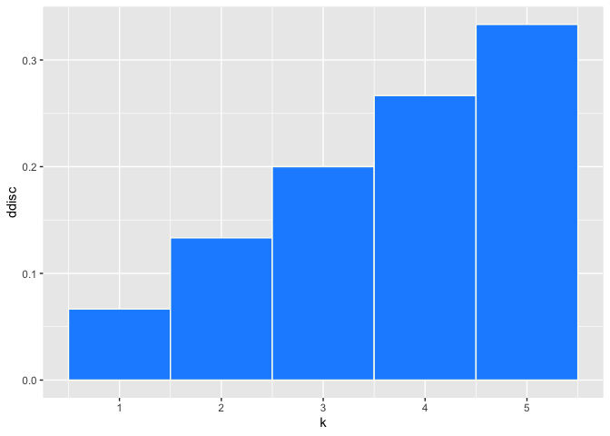

```r
pdfplt <- data.frame(k,ddisc)

(g <- ggplot(pdfplt, aes(x=k,y=ddisc)))+geom_bar(stat="identity", width=1,fill="dodgerblue", color="ivory")
```

plot cdf

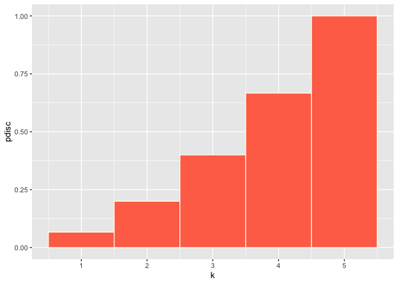

```r
cdfplt <- data.frame(k,pdisc)

(g <- ggplot(cdfplt, aes(x=k,y=pdisc)))+geom_bar(stat="identity", width=1, fill = "coral1", color="ivory")
```

Compute mean and variance

```r
E_x <- sum(k * ddisc)
E_x2 <- sum(k * k * ddisc)
var <- E_x2 - (E_x)**2

E_x
```

```
## [1] 3.666667
```

```r
var
```

```
## [1] 1.555556
```

Compute E[k(6-k)]

```r
E_k = 6*E_x - E_x2
E_k
```

```
## [1] 7
```

Draw random samples from distribution

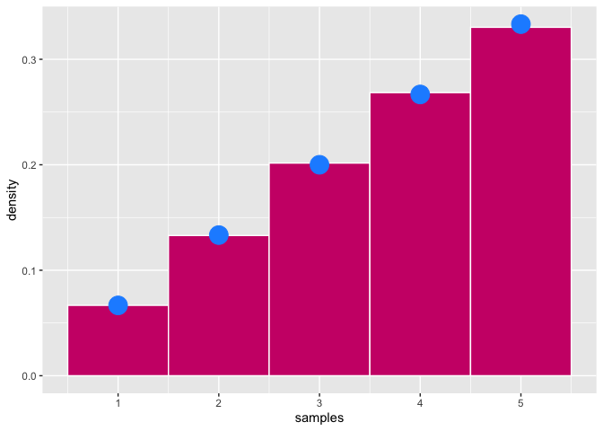

```r
rdisc = function(n) {
  x <- runif(n,0,1)
  y <- ifelse(x < 1/15, 1,
              ifelse(x < 3/15, 2,
                     ifelse(x < 6/15, 3,
                            ifelse(x < 10/15, 4, 5))))

}

sampler <- data.frame(rdisc(10e+4))
colnames(sampler) <- "samples"

(g <- ggplot(sampler) +
   geom_histogram(binwidth=1 ,fill = "deeppink3", color="white",aes(x=samples, y=after_stat(density))) +
   geom_point(data = pdfplt, size=7, color = "dodgerblue", aes(x=k, y=ddisc)))
```

##Exercise 2 - Random continuos variable

Define pdf and cdf

```r
x <- seq(0,5,0.05)
a <- 1
b <- 4
c <- 2

pdf <- ifelse(x<a | x>b, 0, ifelse(x<c, 2*(x-a)/((b-a)*(c-a)), 2*(b-x)/((b-a)*(b-c))))
cdf <- ifelse(x<a, 0,
              ifelse(x<c,(x-a)**2/((b-a)*(c-a)),
                     ifelse(x<b,(c-a)/(b-a)+(2*b*(x-c)-x**2+c**2)/((b-c)*(b-a)),1)))

X <- data.frame(x,pdf,cdf)
```

Plot pdf

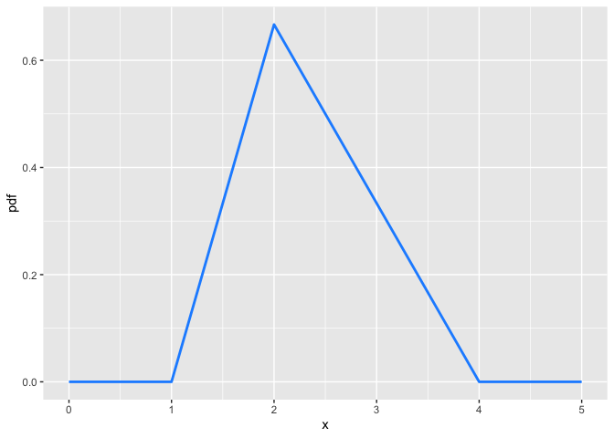

```r
p <- ggplot(X, aes(x=x,y=pdf)) +
     geom_line(lwd=1, color = "dodgerblue")
p
```

Plot cdf

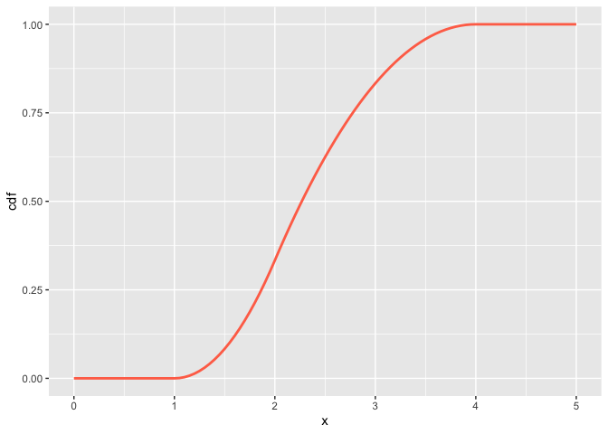

```r
p <- ggplot(X, aes(x=x,y=cdf)) +
     geom_line(lwd=1, color = "coral1")
p
```

Sample from the pdf using the accept/reject method.

```r
samplefunc <- function(N) {
  i <- 1
  SMPL <- rep(0,N)
  while (i<N+1) {
    x <- runif(1,a,b)
    y <- runif(1,0,1)
    if(x<=c) {
      if (y < 2*(x-a)/((b-a)*(c-a))) {
        SMPL[i] <- x
        i <- i+1
      }
    }
    if(x>c) {
      if (y < 2*(b-x)/((b-a)*(b-c))) {
        SMPL[i] <- x
        i <- i+1
      }
    }
  }
  return(SMPL)
}
```

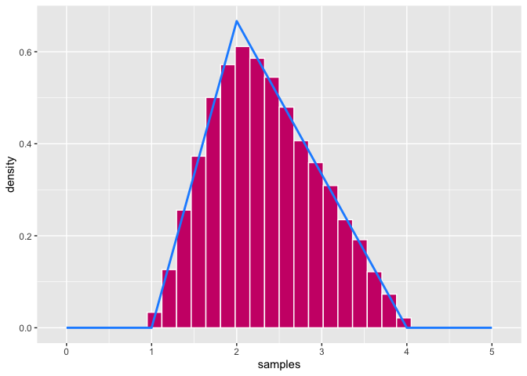

```r
Y <- data.frame(samplefunc(1e+4))
colnames(Y) <- "samples"

(g <- ggplot(Y) +
   geom_histogram(fill = "deeppink3", color="white",aes(x=samples, y=after_stat(density))) +
   geom_line(data = X, lwd=1, color = "dodgerblue", aes(x=x, y=pdf)))
```

##Exercise 3 - Waiting time at the Doctor

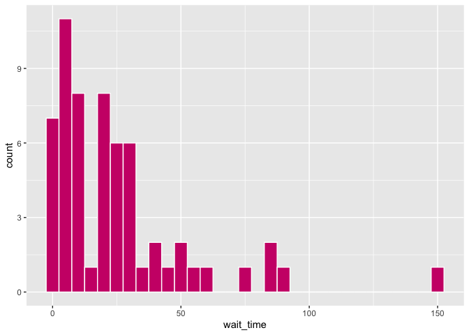

```r
X <- data.frame(rexp(60,1/30))
colnames(X) <- "wait_time"
wt <- mean(X$wait_time)

(g <- ggplot(X, aes(x=wait_time)) + geom_histogram(binwidth= 5, fill = "deeppink3", color="white"))
```

Probability of waiting less than 12 minutes

```r
wt <- pexp(12,1/30)
wt
```

```
## [1] 0.32968
```

Probability of waiting more than 1hr

```r
wt <- 1 - pexp(60,1/30)
wt
```

```
## [1] 0.1353353
```

##Exercise 4 - Multiple choices exam

This is a standard application of the Bayes theorem, where: - R = “right answer” - K = “knows the answer” We have P(K) = 0.7, P(R|not(K)) = 0.2 (so P(not(R)|not(K))=0.8), P(K|R) = ? from the text, we also reasonably assume P(R|K) = 1, and P(not(R)|K)=0

After some algebraic manipulation we get to

P(K|R) = [P(R|K)P(K)]/[P(R|K)P(K)+P(R|not(K))P(not(K))]

```r
a <- (1*0.7)/(1*0.7+0.2*0.3)
a
```

```
## [1] 0.9210526
```

##Exercise 5 - Train waiting time

The first train will leave at 11:00, the next ones would be at 11:30 and 12:00. For time invariance I will draw numbers from 0 (10:45) to 60 (11:45) with train times marked as 15,45,75.

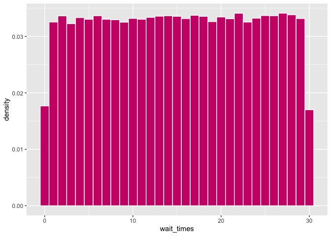

```r
N <- 100000
t <- runif(N,0,60)
wait <- ifelse(t<15,15-t,ifelse(t<45,45-t,75-t))

Y <- data.frame(wait)
colnames(Y) <- "wait_times"

(g <- ggplot(Y, aes(x=wait_times)) + geom_histogram(binwidth=1,fill = "deeppink3", color="white", aes(y=after_stat(density))))
```

Wait at most ten minutes

```r
wt <- length(which(Y$wait_times<=10))/length(Y$wait_times)
wt
```

```
## [1] 0.331
```

Wait at least 15 minutes

```r
wt <- length(which(Y$wait_times>15))/length(Y$wait_times)
wt
```

```
## [1] 0.50174
```

Average waiting time

```r
wt <- mean(Y$wait_times)
wt
```

```
## [1] 15.03788
```

##Exercise 6 - Stock Investment The return on the investment follows a normal distribution. Starting investment is 200*85=17000€ so a profit of 800€ translates to a profit of 4.7%. The solution is easily obtained through the normal cdf

```r
target_perc <- 800/170
prob <- 1 - pnorm(target_perc,10,12)
prob
```

```
## [1] 0.6704574
```